# Frequent Itemset Mining with the Apriori Algorithm

### **Part 3: Generating and Interpreting Association Rules**

Once we have the frequent itemsets, we can use them to generate association rules. We can then filter these rules by a metric like confidence or lift to find the most significant ones.

**Tasks:**

- Generate rules from our frequent itemsets using a minimum confidence threshold.
- Sort the rules by lift to find the most "interesting" associations.

```python
print("\n--- Part 3: Generating and Interpreting Association Rules ---")

# 1. Generate association rules from the frequent itemsets
# We will set a minimum confidence threshold of 0.7
rules = association_rules(frequent_itemsets, metric="confidence", min_threshold=0.7)

print("\nGenerated Association Rules (with confidence >= 0.7):")
# The 'antecedents' and 'consequents' columns contain frozensets, which are immutable sets
print(rules)

# 2. Filter and sort the rules to find the most interesting ones
# Let's look for rules with a high lift (greater than 1) and sort them.
interesting_rules = rules[rules['lift'] > 1].sort_values(by='lift', ascending=False)

print("\n'Interesting' Rules (sorted by Lift):")
print(interesting_rules[['antecedents', 'consequents', 'support', 'confidence', 'lift']])

# INSIGHT & INTERPRETATION:
# The rule {Onion} -> {Eggs} has the highest lift (1.25).
# - Its confidence is 1.0, meaning 100% of the time a customer buys an Onion, they also buy Eggs.
# - Its lift of 1.25 means that a customer is 1.25 times more likely to buy Eggs if they buy an Onion,
#   compared to a random customer. This suggests a meaningful, positive association.
```

```
--- Part 3: Generating and Interpreting Association Rules ---

Generated Association Rules (with confidence >= 0.7):
              antecedents            consequents  antecedent support  \
0          (Kidney Beans)                 (Eggs)                 1.0
1                  (Eggs)         (Kidney Beans)                 0.8
2                  (Eggs)                (Onion)                 0.8
3                 (Onion)                 (Eggs)                 0.6
4                  (Milk)         (Kidney Beans)                 0.6
5                 (Onion)         (Kidney Beans)                 0.6
6                (Yogurt)         (Kidney Beans)                 0.6
7    (Kidney Beans, Eggs)                (Onion)                 0.8
8   (Kidney Beans, Onion)                 (Eggs)                 0.6
9           (Eggs, Onion)         (Kidney Beans)                 0.6
10                 (Eggs)  (Kidney Beans, Onion)                 0.8
```

[output cut: 38 more lines]

### **Lab Tasks & Exercises**

Now, apply what you've learned. The following code cell contains three tasks to help you explore how the Apriori algorithm's parameters and metrics work.

```python
# --- TASK 1: Adjusting the Support Threshold ---
# The support threshold is the most important parameter. Re-run the `apriori` algorithm on the
# one-hot encoded `df` but with a lower `min_support` of 0.5.
# How many frequent itemsets are generated now? What does this tell you about setting this threshold?

# YOUR CODE HERE
# frequent_itemsets_low_support = apriori(df, min_support=0.5, use_colnames=True)
# print("--- Task 1: Frequent itemsets with min_support=0.5 ---")
# print(f"Number of frequent itemsets found: {len(frequent_itemsets_low_support)}")
# print(frequent_itemsets_low_support)


# --- TASK 2: Adjusting the Confidence Threshold ---
# Using the original `frequent_itemsets` (from min_support=0.6), re-run the `association_rules`
# generation, but this time with a very high `min_threshold` for confidence, e.g., 0.9.
# How many rules are generated now? What types of rules are they?

# YOUR CODE HERE
# rules_high_confidence = association_rules(frequent_itemsets, metric="confidence", min_threshold=0.9)
# print("\n--- Task 2: Rules with min_confidence=0.9 ---")
# print(f"Number of rules found: {len(rules_high_confidence)}")
# print(rules_high_confidence)


# --- TASK 3: Rule Interpretation ---
# Look at the full set of original rules (from min_confidence=0.7). Find the rule with the highest confidence.
# Is it the same as the rule with the highest lift?
# Interpret the rule `{Eggs} -> {Kidney Beans}` in plain English, using its support, confidence, and lift values.

# YOUR CODE HERE to find the rule and its values
# rule_to_interpret = rules[rules['antecedents'] == {'Eggs'}]
# print("\n--- Task 3: Interpreting the rule {Eggs} -> {Kidney Beans} ---")
# print(rule_to_interpret[['support', 'confidence', 'lift']])
# print("\nInterpretation:")
# print("This rule has a support of 0.8, meaning Eggs and Kidney Beans appear together in 80% of all transactions.")
# print("It has a confidence of 1.0, meaning that in 100% of the transactions where Eggs were bought, Kidney Beans were also bought.")
# print("It has a lift of 1.0, which means that buying Eggs does not make a customer any more or less likely to buy Kidney Beans than a random customer. The items are statistically independent, so the rule is not very 'interesting'.")
```

### **Part 4: Real-World Dataset & Preprocessing**

We will use the "Online Retail" dataset from the UCI Machine Learning Repository. This is a transnational dataset which contains all the transactions occurring between 01/12/2010 and 09/12/2011 for a UK-based online retail.

**Data Preparation**: This is the most critical part of any real-world analysis. We need to:

1. Load the data.
2. Clean it by removing null values and credit transactions (returns).
3. Transform it from a sales log format into a **one-hot encoded transactional format**, where each row represents a unique invoice and columns represent the items.

```python
print("--- Part 4: Real-World Dataset & Preprocessing ---")

# 1. Load the dataset
# This may take a moment to download
url = 'http://archive.ics.uci.edu/ml/machine-learning-databases/00352/Online%20Retail.xlsx'
df = pd.read_excel(url)

print(f"Original data shape: {df.shape}")
print(df.head())

# 2. Clean the data
# Remove rows with missing InvoiceNo or Description
df.dropna(axis=0, subset=['InvoiceNo', 'Description'], inplace=True)
# Remove leading/trailing spaces from Description
df['Description'] = df['Description'].str.strip()
# Convert InvoiceNo to string to handle both numeric and non-numeric invoices
df['InvoiceNo'] = df['InvoiceNo'].astype('str')
# Remove credit transactions (returns), which are identified by invoices starting with 'C'
df = df[~df['InvoiceNo'].str.contains('C')]

print(f"\nData shape after cleaning: {df.shape}")

# 3. Transform the data into a one-hot encoded transactional format
# We will focus on transactions from a single country for simplicity (e.g., France)
basket = (df[df['Country'] =="France"]
          .groupby(['InvoiceNo', 'Description'])['Quantity']
          .sum().unstack().reset_index().fillna(0)
          .set_index('InvoiceNo'))

# Convert the positive quantities to 1 (item was bought) and 0 otherwise
def encode_units(x):
    if x <= 0:
        return 0
    if x >= 1:
        return 1

basket_sets = basket.applymap(encode_units)
# Drop the 'POSTAGE' column as it's not a sold item
basket_sets.drop('POSTAGE', inplace=True, axis=1)

print("\nSample of the final one-hot encoded transactional data for France:")
print(basket_sets.head())
```

```
--- Part 4: Real-World Dataset & Preprocessing ---
Original data shape: (541909, 8)
  InvoiceNo StockCode                          Description  Quantity  \
0    536365    85123A   WHITE HANGING HEART T-LIGHT HOLDER         6
1    536365     71053                  WHITE METAL LANTERN         6
2    536365    84406B       CREAM CUPID HEARTS COAT HANGER         8
3    536365    84029G  KNITTED UNION FLAG HOT WATER BOTTLE         6
4    536365    84029E       RED WOOLLY HOTTIE WHITE HEART.         6

          InvoiceDate  UnitPrice  CustomerID         Country
0 2010-12-01 08:26:00       2.55     17850.0  United Kingdom
1 2010-12-01 08:26:00       3.39     17850.0  United Kingdom
2 2010-12-01 08:26:00       2.75     17850.0  United Kingdom
3 2010-12-01 08:26:00       3.39     17850.0  United Kingdom
4 2010-12-01 08:26:00       3.39     17850.0  United Kingdom

Data shape after cleaning: (531167, 8)

Sample of the final one-hot encoded transactional data for France:
Description  10 COLOUR SPACEBOY PEN  12 COLOURED PARTY BALLOONS  \
InvoiceNo
536370                            0                           0
536852                            0                           0
536974                            0                           0
537065                            0                           0
537463                            0                           0

Description  12 EGG HOUSE PAINTED WOOD  12 MESSAGE CARDS WITH ENVELOPES  \
InvoiceNo
536370                               0                                0
536852                               0                                0
536974                               0                                0
537065                               0                                0
537463                               0                                0

Description  12 PENCIL SMALL TUBE WOODLAND  \
InvoiceNo
536370                                   0
536852                                   0
536974                                   0
```

[output cut: 53 more lines]

```
536370                                 0                               0
536852                                 0                               0
536974                                 0                               0
537065                                 0                               0
537463                                 0                               0

Description  ZINC T-LIGHT HOLDER STARS SMALL
InvoiceNo
536370                                     0
536852                                     0
536974                                     0
537065                                     0
537463                                     0

[5 rows x 1562 columns]
```

### **Part 5: EDA - Visualizing Top Items**

Before mining for rules, let's explore the data. A simple but effective first step is to identify and visualize the most frequently purchased items. This gives us a sense of the "popular" items that are likely to appear in our frequent itemsets.

```
--- Part 5: EDA - Visualizing Top Items ---
```

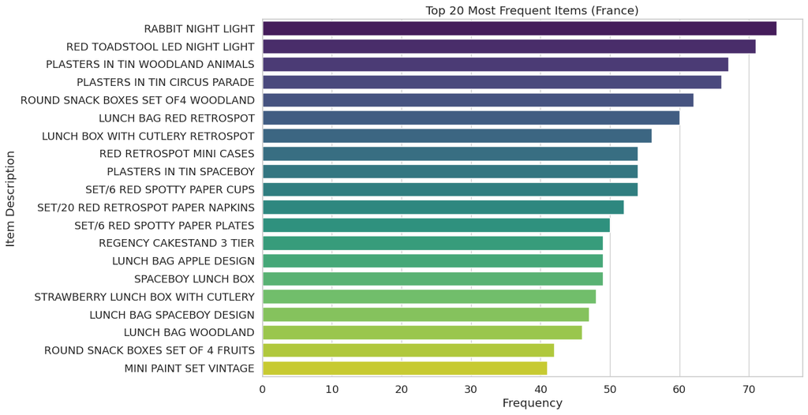

```python
print("\n--- Part 5: EDA - Visualizing Top Items ---")

# Sum up the item frequencies
item_frequencies = basket_sets.sum().sort_values(ascending=False)

# Import matplotlib and seaborn for plotting
import matplotlib.pyplot as plt
import seaborn as sns

# Visualize the top 20 most frequent items
plt.figure(figsize=(12, 8))
sns.barplot(x=item_frequencies.head(20).values, y=item_frequencies.head(20).index, palette='viridis')
plt.title('Top 20 Most Frequent Items (France)')
plt.xlabel('Frequency')
plt.ylabel('Item Description')
plt.show()
```

### **Part 6: Apriori for Frequent Itemset Generation**

Now we apply the Apriori algorithm to our prepared transactional data. The most crucial parameter is `min_support`. For a large dataset with many unique items, this value will typically be very low.

```
--- Part 6: Apriori for Frequent Itemset Generation ---

Top 10 Frequent Itemsets:
     support                              itemsets
46  0.188776                  (RABBIT NIGHT LIGHT)
52  0.181122       (RED TOADSTOOL LED NIGHT LIGHT)
44  0.170918    (PLASTERS IN TIN WOODLAND ANIMALS)
40  0.168367       (PLASTERS IN TIN CIRCUS PARADE)
59  0.158163  (ROUND SNACK BOXES SET OF4 WOODLAND)
26  0.153061             (LUNCH BAG RED RETROSPOT)
31  0.142857    (LUNCH BOX WITH CUTLERY RETROSPOT)
42  0.137755            (PLASTERS IN TIN SPACEBOY)
50  0.137755            (RED RETROSPOT MINI CASES)
65  0.137755         (SET/6 RED SPOTTY PAPER CUPS)
```

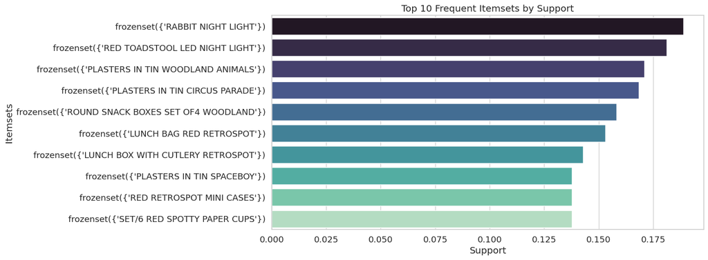

```python
print("\n--- Part 6: Apriori for Frequent Itemset Generation ---")

# 1. Run the Apriori algorithm
# We will set a low min_support of 0.05
frequent_itemsets = apriori(basket_sets, min_support=0.05, use_colnames=True)

# Sort by support for better readability
frequent_itemsets = frequent_itemsets.sort_values(by='support', ascending=False)

print("\nTop 10 Frequent Itemsets:")
print(frequent_itemsets.head(10))

# Visualize the support of the top 10 frequent itemsets
plt.figure(figsize=(12, 6))
sns.barplot(x=frequent_itemsets['support'].head(10), y=[str(item) for item in frequent_itemsets['itemsets'].head(10)], palette='mako')
plt.title('Top 10 Frequent Itemsets by Support')
plt.xlabel('Support')
plt.ylabel('Itemsets')
plt.show()
```

### **Part 7: Generating and Visualizing Association Rules**

With our frequent itemsets, we can now generate association rules. We'll filter these rules by a metric like **lift** to find the most interesting and non-obvious relationships. A powerful way to analyze the rules is to plot them on a scatter plot to see the interplay between support, confidence, and lift.

```
--- Part 7: Generating and Visualizing Association Rules ---

Top Strong Association Rules (Lift >= 6, Confidence >= 0.8):
                                          antecedents  \
79                       (PACK OF 6 SKULL PAPER CUPS)
78                     (PACK OF 6 SKULL PAPER PLATES)
36                       (CHILDRENS CUTLERY SPACEBOY)
37                     (CHILDRENS CUTLERY DOLLY GIRL)
47  (ALARM CLOCK BAKELIKE GREEN, ALARM CLOCK BAKEL...
48  (ALARM CLOCK BAKELIKE RED, ALARM CLOCK BAKELIK...
18                       (ALARM CLOCK BAKELIKE GREEN)
19                         (ALARM CLOCK BAKELIKE RED)
46  (ALARM CLOCK BAKELIKE GREEN, ALARM CLOCK BAKEL...
12  (SET/20 RED RETROSPOT PAPER NAPKINS, SET/6 RED...
10  (SET/6 RED SPOTTY PAPER PLATES, SET/20 RED RET...
```

[output cut: 55 more lines]

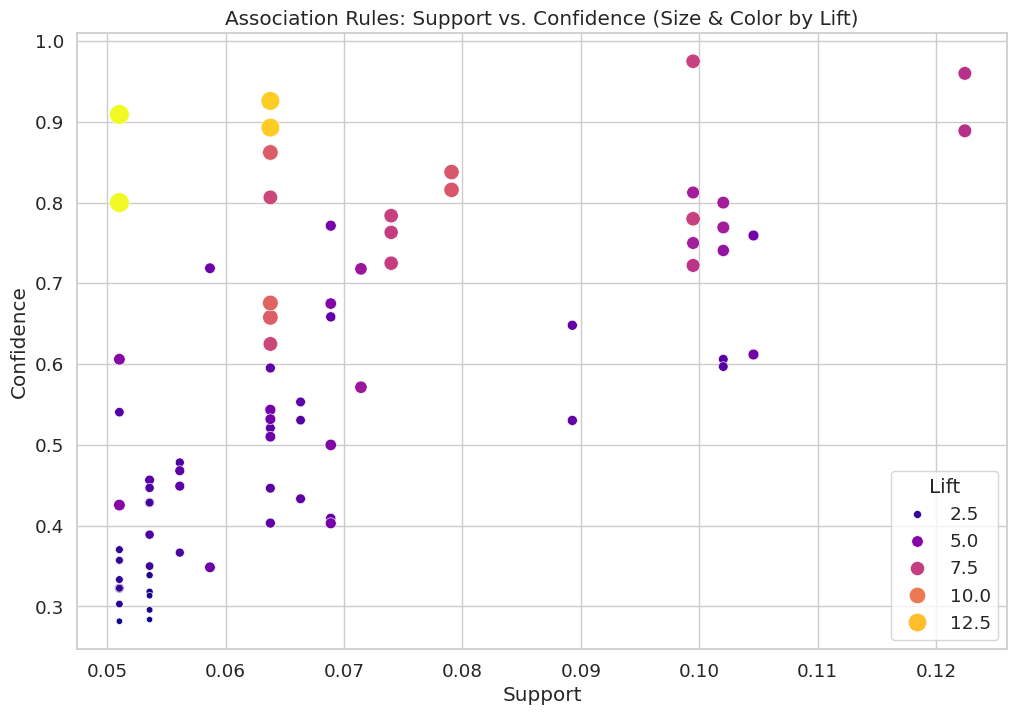

```python
print("\n--- Part 7: Generating and Visualizing Association Rules ---")

# 1. Generate association rules
# We will filter for rules with a lift of at least 6 and a confidence of at least 0.8
rules = association_rules(frequent_itemsets, metric="lift", min_threshold=1)
strong_rules = rules[(rules['lift'] >= 6) & (rules['confidence'] >= 0.8)]

# Sort the strong rules by lift
strong_rules = strong_rules.sort_values(by='lift', ascending=False)

print("\nTop Strong Association Rules (Lift >= 6, Confidence >= 0.8):")
print(strong_rules)

# 2. Visualize the rules on a scatter plot
plt.figure(figsize=(12, 8))
sns.scatterplot(x=rules['support'], y=rules['confidence'], size=rules['lift'], hue=rules['lift'], palette='plasma', sizes=(20, 200))
plt.title('Association Rules: Support vs. Confidence (Size & Color by Lift)')
plt.xlabel('Support')
plt.ylabel('Confidence')
plt.legend(title='Lift')
plt.show()

# INSIGHT: The scatter plot helps us identify the "best" rules. We look for points in the top-right corner (high support & confidence)
# that also have a large size and bright color (high lift).
```

### **Part 8: Network Graph of Association Rules**

Visualizing the rules as a network graph provides an intuitive way to understand the connections between items. Nodes in the graph represent items, and the directed edges represent the association rules.

```
--- Part 8: Network Graph of Association Rules ---
```

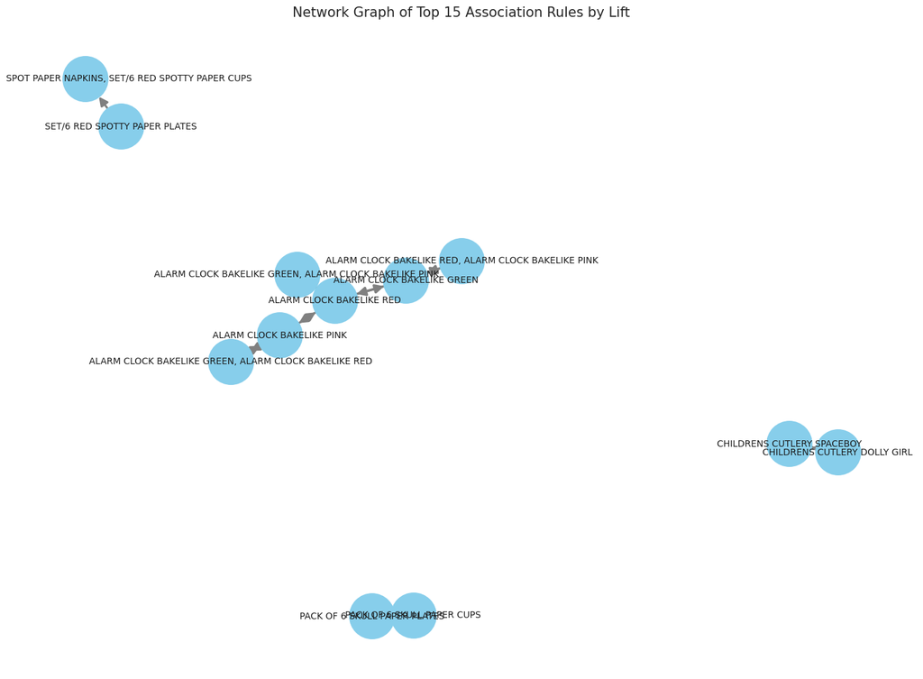

```python
print("\n--- Part 8: Network Graph of Association Rules ---")

# We will visualize a subset of the rules for clarity
graph_rules = rules.nlargest(15, 'lift') # Select top 15 rules by lift

# Import networkx for graph visualization
import networkx as nx
import matplotlib.pyplot as plt

# Create a directed graph
G = nx.DiGraph()

# Add nodes and edges from the rules
for i, row in graph_rules.iterrows():
    antecedent = ', '.join(list(row['antecedents']))
    consequent = ', '.join(list(row['consequents']))
    G.add_edge(antecedent, consequent, weight=row['lift'])

# Draw the network graph
plt.figure(figsize=(14, 10))
pos = nx.spring_layout(G, k=0.5, iterations=50) # Layout algorithm
nx.draw(G, pos, with_labels=True, node_size=2500, node_color='skyblue', font_size=10,
        width=[G[u][v]['weight']*0.3 for u, v in G.edges()], # Edge width proportional to lift
        edge_color='gray', arrowsize=20)

plt.title('Network Graph of Top 15 Association Rules by Lift', size=15)
plt.show()
```